# ANALYSIS OF INTEREST RATES (IR)

## Project Description

- Download USD and CAD LIBOR data for multiple tenors from FRED’s web site
- Check data for gaps, sudden jumps and other data quality issues
- Plot time series of IRs and their 1-day and 30-day increments using either xtspackage
- Plot histogram of IRs and their 1-day and 30-day increments, and compare it to several distribution fits
- Calculate and plot average term structure of IR and its standard deviation
- Plot correlation matrix using corrplotpackage for correlation of the increments between various tenors
- Calculate and plot three first principal components of IR. How much total variance do they explain?
- Estimate the scaling factor between the 1-day and 30-day increments. How does it depend on the estimation time period?
- Fit Vasicekmodel to each tenor using sdepackage
- Join the fitted Vasicekmodels by using correlated Brownian motions simulated using the first three principal components
- Enhance the model by replacing constant volatility assumption by a stochastic volatility model

## Libor Rate Data Sources

LIBOR interest rate data is obtained for the following terms: Over-night, 1-week, 1-month, 3-month, 6-month, and 1-year. The source of the data is the [Federal Reserve Bank of St. Louis](https://research.stlouisfed.org/) .

## Load Libraries and Set Global Parameters

This project utilizes xts, ggplot2, and reshape2 packages. The xts package is useful for storing time series data. The ggplot2 package is a well known plotting package used to generate the graphs. The reshape2 package is used to structure data to allow for easier computation or plotting. Several other libraries, including fitdistrplus, yuima, Hmics etc. have been used to model interest rates and and anylze the behaviour and trends.

```r
rm(list=ls())
options(warn=-1)
```

```r
packages =  c('ggplot2', 'corrplot', 'gridExtra', 'forecast', 'tseries', 'TSA', 'scatterplot3d',
              'quantmod', 'factoextra', 'xts', 'dygraphs', 'assertthat', 'Quandl', 'bootstrap',
              'sde','Hmisc','rgl','RColorBrewer', 'devtools', 'Sim.DiffProc','lubridate',
              'reshape', 'quantmod', 'reticulate','PerformanceAnalytics', 'fitdistrplus', 'yuima')
my.install <- function(pkg, ...){
  if (!(pkg %in% installed.packages()[,1])) {
    install.packages(pkg)
  }
  return (library(pkg, ...))
}
purrr::walk(packages, my.install, character.only = TRUE, warn.conflicts = FALSE)
currentDate <- Sys.Date()
eopm <- currentDate - days(day(currentDate))
sopm <- currentDate - days(day(currentDate))
sopm <- sopm - days(day(sopm) - 1)
```

## Load Libor Data

```r
LIBOR = getSymbols(src="FRED",Symbols=c("USDONTD156N", "USD1WKD156N", "USD1MTD156N",
                                         "USD2MTD156N", "USD3MTD156N", "USD6MTD156N", "USD12MD156N",
                                         "CADONTD156N","CAD1WKD156N","CAD1MTD156N",
                                         "CAD2MTD156N","CAD3MTD156N","CAD6MTD156N","CAD12MD156N"))
```

[output not shown]

## Data Overview

```r
summary(rates_USD)
```

```
     Index             USDONTD156N     USD1WKD156N     USD1MTD156N       USD2MTD156N       USD3MTD156N       USD6MTD156N
 Min.   :1986-01-02   Min.   :0.080   Min.   :0.116   Min.   : 0.1477   Min.   : 0.1890   Min.   : 0.2228   Min.   : 0.3194
 1st Qu.:1994-03-26   1st Qu.:0.159   1st Qu.:0.238   1st Qu.: 0.9243   1st Qu.: 0.9274   1st Qu.: 1.1200   1st Qu.: 1.2483
 Median :2002-06-18   Median :1.048   Median :1.322   Median : 3.6250   Median : 3.5000   Median : 3.7500   Median : 3.8400
 Mean   :2002-06-17   Mean   :1.582   Mean   :2.217   Mean   : 3.6677   Mean   : 3.6267   Mean   : 3.7771   Mean   : 3.9017
 3rd Qu.:2010-09-08   3rd Qu.:2.183   3rd Qu.:4.560   3rd Qu.: 5.6875   3rd Qu.: 5.6875   3rd Qu.: 5.8125   3rd Qu.: 5.8750
 Max.   :2018-11-30   Max.   :6.875   Max.   :7.756   Max.   :10.3125   Max.   :10.4375   Max.   :10.6250   Max.   :11.0000
                      NA's   :4181    NA's   :3281    NA's   :267       NA's   :521       NA's   :267       NA's   :267
  USD12MD156N
 Min.   : 0.5335
 1st Qu.: 1.5039
 Median : 4.0625
 Mean   : 4.1284
 3rd Qu.: 6.0403
 Max.   :11.3750
 NA's   :267
```

```r
str(rates_USD)
```

```
An ‘xts’ object on 1986-01-02/2018-11-30 containing:
  Data: num [1:8587, 1:7] NA NA NA NA NA NA NA NA NA NA ...
 - attr(*, "dimnames")=List of 2
  ..$ : NULL
  ..$ : chr [1:7] "USDONTD156N" "USD1WKD156N" "USD1MTD156N" "USD2MTD156N" ...
  Indexed by objects of class: [Date] TZ: UTC
  xts Attributes:
List of 2
 $ src    : chr "FRED"
 $ updated: POSIXct[1:1], format: "2018-12-08 12:03:27"
```

```r
summary(rates)
```

```
     Index             USD1MTD156N       USD2MTD156N       USD3MTD156N       USD6MTD156N       USD12MD156N
 Min.   :1986-01-02   Min.   : 0.1477   Min.   : 0.1890   Min.   : 0.2228   Min.   : 0.3194   Min.   : 0.5335
 1st Qu.:1994-03-26   1st Qu.: 0.9243   1st Qu.: 0.9274   1st Qu.: 1.1200   1st Qu.: 1.2483   1st Qu.: 1.5039
 Median :2002-06-18   Median : 3.6250   Median : 3.5000   Median : 3.7500   Median : 3.8400   Median : 4.0625
 Mean   :2002-06-17   Mean   : 3.6677   Mean   : 3.6267   Mean   : 3.7771   Mean   : 3.9017   Mean   : 4.1284
 3rd Qu.:2010-09-08   3rd Qu.: 5.6875   3rd Qu.: 5.6875   3rd Qu.: 5.8125   3rd Qu.: 5.8750   3rd Qu.: 6.0403
 Max.   :2018-11-30   Max.   :10.3125   Max.   :10.4375   Max.   :10.6250   Max.   :11.0000   Max.   :11.3750
                      NA's   :267       NA's   :521       NA's   :267       NA's   :267       NA's   :267
```

```r
str(rates)
```

```
An ‘xts’ object on 1986-01-02/2018-11-30 containing:
  Data: num [1:8587, 1:5] 8.12 8.12 8.19 8.12 8 ...
 - attr(*, "dimnames")=List of 2
  ..$ : NULL
  ..$ : chr [1:5] "USD1MTD156N" "USD2MTD156N" "USD3MTD156N" "USD6MTD156N" ...
  Indexed by objects of class: [Date] TZ: UTC
  xts Attributes:
List of 2
 $ src    : chr "FRED"
 $ updated: POSIXct[1:1], format: "2018-12-08 12:03:28"
```

## Data Cleaning

```r
rates_USD = na.approx(rates_USD)
rates_CDN = na.approx(rates_CDN)
rates = na.approx(rates)
rates_USD[is.na(rates_USD)] = 0
rates_CDN = na.omit(rates_CDN)
rates = na.omit(rates)
dataframe_USD = data.frame(index(rates_USD), rates_USD)
dataframe_CDN = data.frame(index(rates_CDN), rates_CDN)
dataframe = data.frame(index(rates), rates)
colnames(dataframe_USD) = c('date', 'ON', '1WK', '1M', '2M', '3M', '6M', '12M')
colnames(dataframe_CDN) = c('date', '1M', '2M', '3M', '6M', '12M')
colnames(dataframe) = c('date', '1M', '2M', '3M', '6M', '12M')
dataframe_USD$date = as.Date(dataframe_USD$date, format = "%Y-%m-%d")
dataframe_CDN$date = as.Date(dataframe_CDN$date, format = "%Y-%m-%d")
dataframe$date = as.Date(dataframe$date, format = "%Y-%m-%d")
summary(dataframe)
```

```
      date                  1M                2M                3M                6M               12M
 Min.   :1987-01-02   Min.   : 0.1477   Min.   : 0.1890   Min.   : 0.2228   Min.   : 0.3194   Min.   : 0.5335
 1st Qu.:1994-12-26   1st Qu.: 0.6679   1st Qu.: 0.9176   1st Qu.: 1.1100   1st Qu.: 1.2252   1st Qu.: 1.4600
 Median :2002-12-17   Median : 3.3750   Median : 3.5000   Median : 3.5000   Median : 3.6250   Median : 3.8541
 Mean   :2002-12-17   Mean   : 3.5653   Mean   : 3.6252   Mean   : 3.6802   Mean   : 3.8093   Mean   : 4.0405
 3rd Qu.:2010-12-08   3rd Qu.: 5.6562   3rd Qu.: 5.6875   3rd Qu.: 5.6914   3rd Qu.: 5.8096   3rd Qu.: 5.9375
 Max.   :2018-11-30   Max.   :10.3125   Max.   :10.4375   Max.   :10.6250   Max.   :11.0000   Max.   :11.3750
```

```r
str(dataframe)
```

```
'data.frame':   8326 obs. of  6 variables:
 $ date: Date, format: "1987-01-02" "1987-01-05" "1987-01-06" "1987-01-07" ...
 $ 1M  : num  6.5 6.38 6.38 6.38 6.25 ...
 $ 2M  : num  6.38 6.31 6.31 6.31 6.19 ...
 $ 3M  : num  6.31 6.25 6.25 6.25 6.12 ...
 $ 6M  : num  6.25 6.25 6.19 6.19 6.12 ...
 $ 12M : num  6.25 6.25 6.19 6.19 6.12 ...
```

## Let’s have a look at some univariate distributions

### 7.1. Interest Rate vs Time

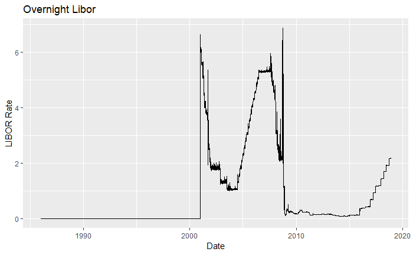

```r
p1 = ggplot(dataframe_USD, aes(x = dataframe_USD$date, y = dataframe_USD$ON)) + geom_line() + xlab('Date') + ylab('LIBOR Rate') + ggtitle('Overnight Libor')
p1
```

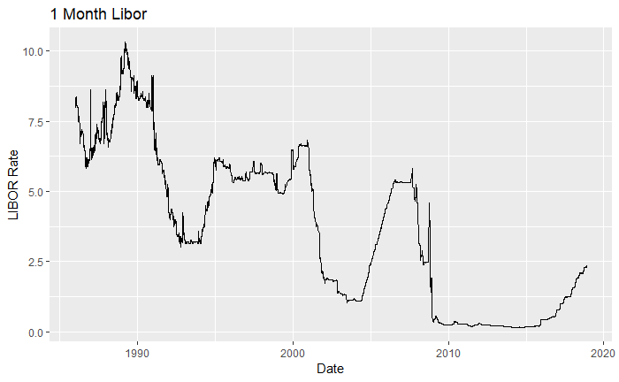

```r
p3 = ggplot(dataframe_USD, aes(x = dataframe_USD$date, y = dataframe_USD$`1M`)) + geom_line() + xlab('Date') + ylab('LIBOR Rate')+ ggtitle('1 Month Libor')
p3
```

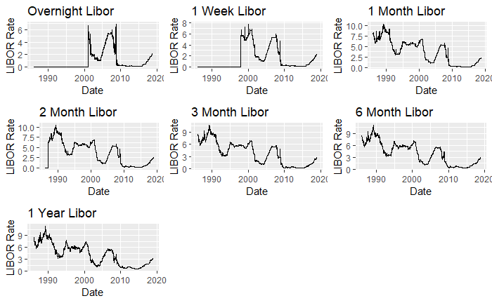

```r
options(repr.plot.width=12, repr.plot.height=12)
p2 = ggplot(dataframe_USD, aes(x = dataframe_USD$date, y = dataframe_USD$`1WK`)) + geom_line() + xlab('Date') + ylab('LIBOR Rate')+ ggtitle('1 Week Libor')
p4 = ggplot(dataframe_USD, aes(x = dataframe_USD$date, y = dataframe_USD$`2M`)) + geom_line() + xlab('Date') + ylab('LIBOR Rate')+ ggtitle('2 Month Libor')
p5 = ggplot(dataframe_USD, aes(x = dataframe_USD$date, y = dataframe_USD$`3M`)) + geom_line() + xlab('Date') + ylab('LIBOR Rate')+ ggtitle('3 Month Libor')
p6 = ggplot(dataframe_USD, aes(x = dataframe_USD$date, y = dataframe_USD$`6M`)) + geom_line() + xlab('Date') + ylab('LIBOR Rate')+ ggtitle('6 Month Libor')
p7 = ggplot(dataframe_USD, aes(x = dataframe_USD$date, y = dataframe_USD$`12M`)) + geom_line() + xlab('Date') + ylab('LIBOR Rate')+ ggtitle('1 Year Libor')
grid.arrange(p1,p2,p3,p4,p5,p6,p7, nrow=3,ncol=3)
```

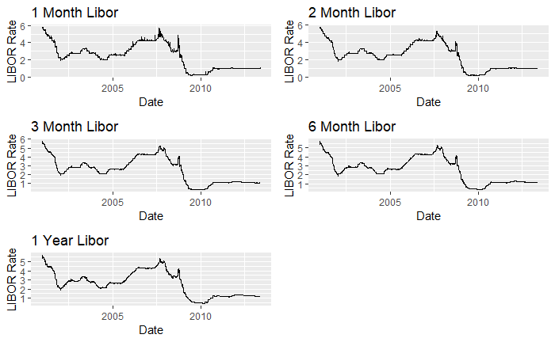

```r
p1 = ggplot(dataframe_CDN, aes(x = dataframe_CDN$date, y = dataframe_CDN$`1M`)) + geom_line() + xlab('Date') + ylab('LIBOR Rate')+ ggtitle('1 Month Libor')
p2 = ggplot(dataframe_CDN, aes(x = dataframe_CDN$date, y = dataframe_CDN$`2M`)) + geom_line() + xlab('Date') + ylab('LIBOR Rate')+ ggtitle('2 Month Libor')
p3 = ggplot(dataframe_CDN, aes(x = dataframe_CDN$date, y = dataframe_CDN$`3M`)) + geom_line() + xlab('Date') + ylab('LIBOR Rate')+ ggtitle('3 Month Libor')
p4 = ggplot(dataframe_CDN, aes(x = dataframe_CDN$date, y = dataframe_CDN$`6M`)) + geom_line() + xlab('Date') + ylab('LIBOR Rate')+ ggtitle('6 Month Libor')
p5 = ggplot(dataframe_CDN, aes(x = dataframe_CDN$date, y = dataframe_CDN$`12M`)) + geom_line() + xlab('Date') + ylab('LIBOR Rate')+ ggtitle('1 Year Libor')
grid.arrange(p1,p2,p3,p4,p5, nrow=3,ncol=2)
```

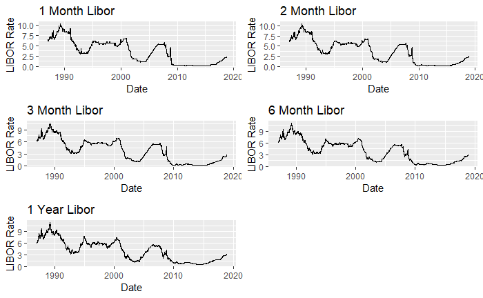

```r
p1 = ggplot(dataframe, aes(x = dataframe$date, y = dataframe$`1M`)) + geom_line() + xlab('Date') + ylab('LIBOR Rate')+ ggtitle('1 Month Libor')
p2 = ggplot(dataframe, aes(x = dataframe$date, y = dataframe$`2M`)) + geom_line() + xlab('Date') + ylab('LIBOR Rate')+ ggtitle('2 Month Libor')
p3 = ggplot(dataframe, aes(x = dataframe$date, y = dataframe$`3M`)) + geom_line() + xlab('Date') + ylab('LIBOR Rate')+ ggtitle('3 Month Libor')
p4 = ggplot(dataframe, aes(x = dataframe$date, y = dataframe$`6M`)) + geom_line() + xlab('Date') + ylab('LIBOR Rate')+ ggtitle('6 Month Libor')
p5 = ggplot(dataframe, aes(x = dataframe$date, y = dataframe$`12M`)) + geom_line() + xlab('Date') + ylab('LIBOR Rate')+ ggtitle('1 Year Libor')
grid.arrange(p1,p2,p3,p4,p5, nrow=3,ncol=2)
```

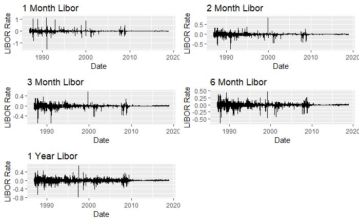

```r
xtsdiff1 = diff(rates, differences=1)
xtsdiff1 = na.exclude(xtsdiff1)
dataframe_diff1 = fortify(xtsdiff1)
p1 = ggplot(dataframe_diff1, aes(x = dataframe_diff1$Index, y = dataframe_diff1$USD1MTD156N)) + geom_line() + xlab('Date') + ylab('LIBOR Rate')+ ggtitle('1 Month Libor')
p2 = ggplot(dataframe_diff1, aes(x = dataframe_diff1$Index, y = dataframe_diff1$USD2MTD156N)) + geom_line() + xlab('Date') + ylab('LIBOR Rate')+ ggtitle('2 Month Libor')
p3 = ggplot(dataframe_diff1, aes(x = dataframe_diff1$Index, y = dataframe_diff1$USD3MTD156N)) + geom_line() + xlab('Date') + ylab('LIBOR Rate')+ ggtitle('3 Month Libor')
p4 = ggplot(dataframe_diff1, aes(x = dataframe_diff1$Index, y = dataframe_diff1$USD6MTD156N)) + geom_line() + xlab('Date') + ylab('LIBOR Rate')+ ggtitle('6 Month Libor')
p5 = ggplot(dataframe_diff1, aes(x = dataframe_diff1$Index, y = dataframe_diff1$USD12MD156N)) + geom_line() + xlab('Date') + ylab('LIBOR Rate')+ ggtitle('1 Year Libor')
grid.arrange(p1,p2,p3,p4,p5, nrow=3,ncol=2)
```

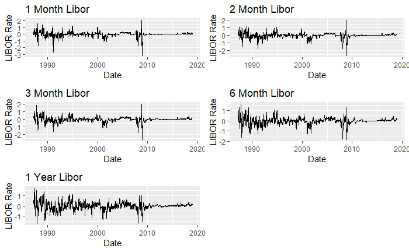

```r
xtsdiff30 = diff(rates, differences=1, lag = 30)
xtsdiff30 = na.exclude(xtsdiff30)
dataframe_diff30 = fortify(xtsdiff30)
p1 = ggplot(dataframe_diff30, aes(x = dataframe_diff30$Index, y = dataframe_diff30$USD1MTD156N)) + geom_line() + xlab('Date') + ylab('LIBOR Rate')+ ggtitle('1 Month Libor')
p2 = ggplot(dataframe_diff30, aes(x = dataframe_diff30$Index, y = dataframe_diff30$USD2MTD156N)) + geom_line() + xlab('Date') + ylab('LIBOR Rate')+ ggtitle('2 Month Libor')
p3 = ggplot(dataframe_diff30, aes(x = dataframe_diff30$Index, y = dataframe_diff30$USD3MTD156N)) + geom_line() + xlab('Date') + ylab('LIBOR Rate')+ ggtitle('3 Month Libor')
p4 = ggplot(dataframe_diff30, aes(x = dataframe_diff30$Index, y = dataframe_diff30$USD6MTD156N)) + geom_line() + xlab('Date') + ylab('LIBOR Rate')+ ggtitle('6 Month Libor')
p5 = ggplot(dataframe_diff30, aes(x = dataframe_diff30$Index, y = dataframe_diff30$USD12MD156N)) + geom_line() + xlab('Date') + ylab('LIBOR Rate')+ ggtitle('1 Year Libor')
grid.arrange(p1,p2,p3,p4,p5, nrow=3,ncol=2)
```

#### We can clearly see two major jumps

1. Late 1980s - early 1990s:Throughout 1989 and 1990, the economy was weakening as a result of restrictive monetary policy enacted by the Federal Reserve
2. 2008 economic cricis: The Great Recession stemmed from collapse of the United States real-estate market, in relation to the financial crisis of 2007 to 2008 and U.S. subprime mortgage crisis of 2007 to 2009, though policies of other nations contributed also.

### 7.2. Frequency Plot

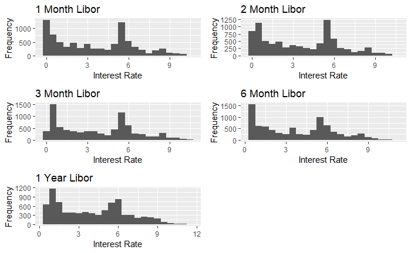

```r
h1 = ggplot(dataframe, aes(dataframe$`1M`)) + geom_histogram(binwidth = 0.5) + xlab('Interest Rate') + ylab('Frequency')+ ggtitle('1 Month Libor')
h2 = ggplot(dataframe, aes(dataframe$`2M`)) + geom_histogram(binwidth = 0.5) + xlab('Interest Rate') + ylab('Frequency')+ ggtitle('2 Month Libor')
h3 = ggplot(dataframe, aes(dataframe$`3M`)) + geom_histogram(binwidth = 0.5) + xlab('Interest Rate') + ylab('Frequency')+ ggtitle('3 Month Libor')
h4 = ggplot(dataframe, aes(dataframe$`6M`)) + geom_histogram(binwidth = 0.5) + xlab('Interest Rate') + ylab('Frequency')+ ggtitle('6 Month Libor')
h5 = ggplot(dataframe, aes(dataframe$`12M`)) + geom_histogram(binwidth = 0.5) + xlab('Interest Rate') + ylab('Frequency')+ ggtitle('1 Year Libor')
grid.arrange(h1,h2,h3,h4,h5, nrow=3,ncol=2)
```

#### Let’s take the first order difference and see how the frequency plot looks with a lag of 1 and 30

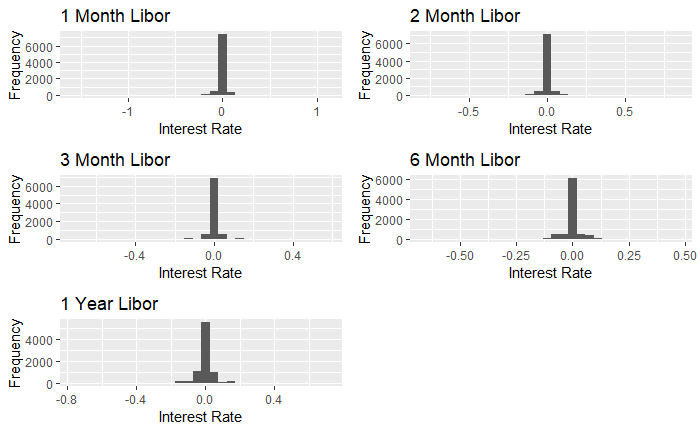

```r
h1 = ggplot(xtsdiff1, aes(xtsdiff1$USD1MTD156N)) + geom_histogram() + xlab('Interest Rate') + ylab('Frequency')+ ggtitle('1 Month Libor')
h2 = ggplot(xtsdiff1, aes(xtsdiff1$USD2MTD156N)) + geom_histogram() + xlab('Interest Rate') + ylab('Frequency')+ ggtitle('2 Month Libor')
h3 = ggplot(xtsdiff1, aes(xtsdiff1$USD3MTD156N)) + geom_histogram() + xlab('Interest Rate') + ylab('Frequency')+ ggtitle('3 Month Libor')
h4 = ggplot(xtsdiff1, aes(xtsdiff1$USD6MTD156N)) + geom_histogram() + xlab('Interest Rate') + ylab('Frequency')+ ggtitle('6 Month Libor')
h5 = ggplot(xtsdiff1, aes(xtsdiff1$USD12MD156N)) + geom_histogram() + xlab('Interest Rate') + ylab('Frequency')+ ggtitle('1 Year Libor')
grid.arrange(h1,h2,h3,h4,h5, nrow=3,ncol=2)
```

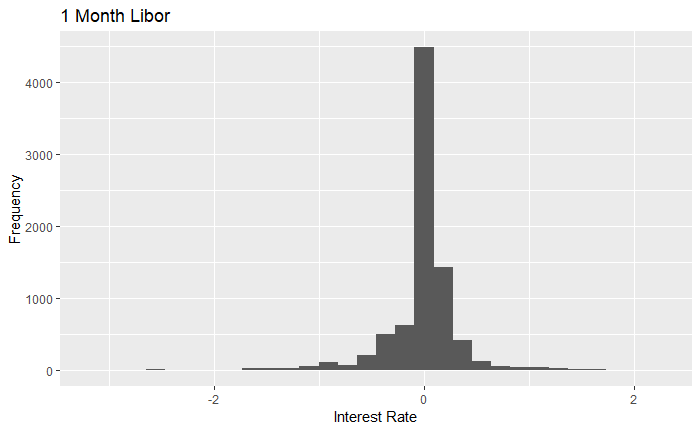

```r
h1 = ggplot(xtsdiff30, aes(xtsdiff30$USD1MTD156N)) + geom_histogram() + xlab('Interest Rate') + ylab('Frequency')+ ggtitle('1 Month Libor')
h1
```

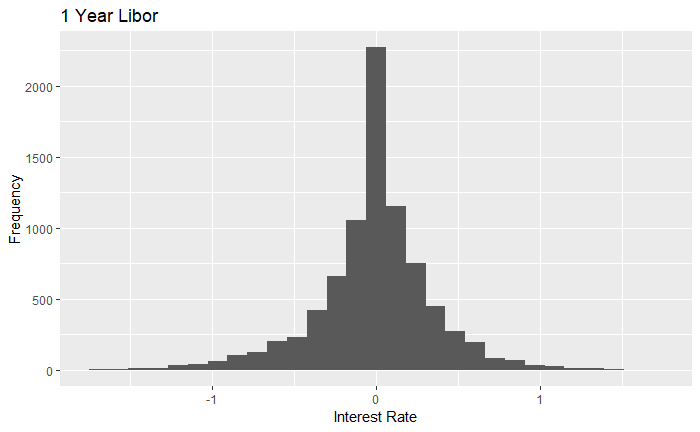

```r
h5 = ggplot(xtsdiff30, aes(xtsdiff30$USD12MD156N)) + geom_histogram() + xlab('Interest Rate') + ylab('Frequency')+ ggtitle('1 Year Libor')
h5
```

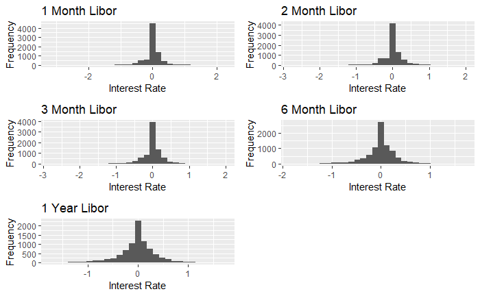

```r
h2 = ggplot(xtsdiff30, aes(xtsdiff30$USD2MTD156N)) + geom_histogram() + xlab('Interest Rate') + ylab('Frequency')+ ggtitle('2 Month Libor')
h3 = ggplot(xtsdiff30, aes(xtsdiff30$USD3MTD156N)) + geom_histogram() + xlab('Interest Rate') + ylab('Frequency')+ ggtitle('3 Month Libor')
h4 = ggplot(xtsdiff30, aes(xtsdiff30$USD6MTD156N)) + geom_histogram() + xlab('Interest Rate') + ylab('Frequency')+ ggtitle('6 Month Libor')
grid.arrange(h1,h2,h3,h4,h5, nrow=3,ncol=2)
```

```r
rates_resampled = period.apply(rates, endpoints(rates, k=2, "week"), mean)
xtsdiff1_resampled = diff(rates_resampled, differences=1)
```

```r
# h1 = ggplot(xtsdiff1_resampled, aes(xtsdiff1_resampled$USD1MTD156N)) + geom_histogram() + xlab('Interest Rate') + ylab('Frequency')+ ggtitle('1 Month Libor')
# h1
```

```r
# h2 = ggplot(xtsdiff1_resampled, aes(xtsdiff1_resampled$USD2MTD156N)) + geom_histogram() + xlab('Interest Rate') + ylab('Frequency')+ ggtitle('2 Month Libor')
# h2
```

```r
# h3 = ggplot(xtsdiff1_resampled, aes(xtsdiff1_resampled$USD3MTD156N)) + geom_histogram() + xlab('Interest Rate') + ylab('Frequency')+ ggtitle('3 Month Libor')
# h4 = ggplot(xtsdiff1_resampled, aes(xtsdiff1_resampled$USD6MTD156N)) + geom_histogram() + xlab('Interest Rate') + ylab('Frequency')+ ggtitle('6 Month Libor')
# h5 = ggplot(xtsdiff1_resampled, aes(xtsdiff1_resampled$USD12MD156N)) + geom_histogram() + xlab('Interest Rate') + ylab('Frequency')+ ggtitle('1 Year Libor')
#
# grid.arrange(h1,h2,h3,h4,h5, nrow=3,ncol=2)
```

```r
normal_dist <- fitdist(dataframe_diff1$USD1MTD156N, "norm")
```

```
NaNs producedNaNs produced
```

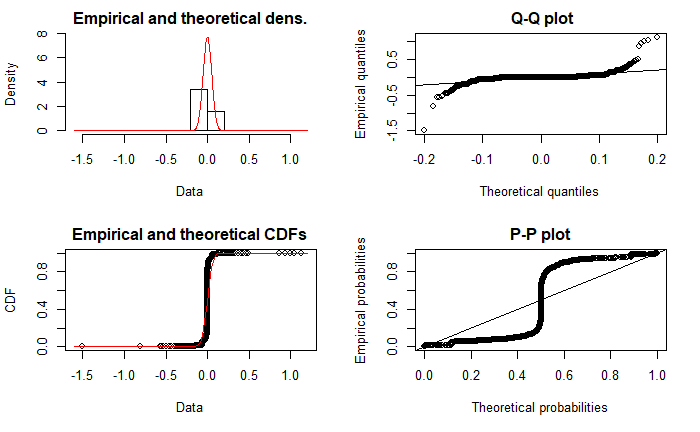

```r
plot(normal_dist)
```

#### Cullen Frey diagram for first order difference with a lag of 1

```
summary statistics
------
min:  -1.5   max:  1.125
median:  0
mean:  -0.0004988661
estimated sd:  0.05179756
estimated skewness:  0.2925306
estimated kurtosis:  198.6593
```

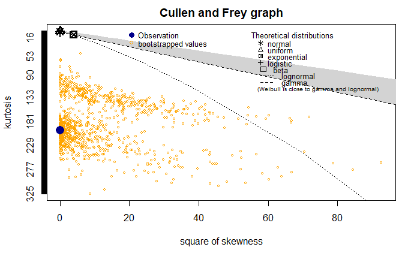

```r
descdist(dataframe_diff1$USD1MTD156N, boot = 1000)
```

```
summary statistics
------
min:  -0.76562   max:  0.67187
median:  0
mean:  -0.0003759459
estimated sd:  0.05246177
estimated skewness:  -0.7088911
estimated kurtosis:  26.88191
```

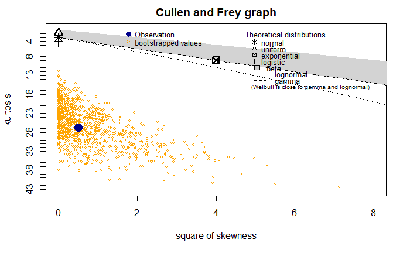

```r
descdist(dataframe_diff1$USD12MD156N, boot = 1000)
```

```r
# fw = fitdist(dataframe_diff1$USD1MTD156N, "weibull")
# fg = fitdist(dataframe_diff1$USD1MTD156N, "gamma")
# fln = fitdist(dataframe_diff1$USD1MTD156N, "lnorm")
# par(mfrow = c(2, 2))
# plot.legend = c("Weibull", "lognormal", "gamma")
# denscomp(list(fw, fln, fg), legendtext = plot.legend)
# qqcomp(list(fw, fln, fg), legendtext = plot.legend)
# cdfcomp(list(fw, fln, fg), legendtext = plot.legend)
# ppcomp(list(fw, fln, fg), legendtext = plot.legend)
```

```r
normal_dist <- fitdist(dataframe_diff30$USD1MTD156N, "norm")
```

```
NaNs producedNaNs produced
```

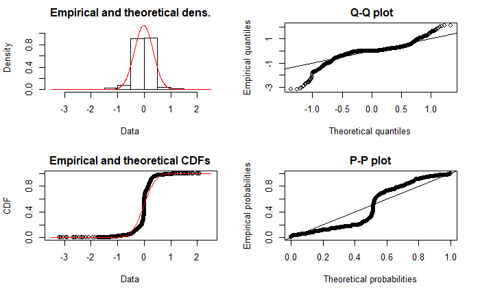

```r
plot(normal_dist)
```

#### Cullen Frey diagram for first order difference with a lag of 30

```
summary statistics
------
min:  -3.1925   max:  2.10187
median:  0
mean:  -0.01435616
estimated sd:  0.3504412
estimated skewness:  -1.521455
estimated kurtosis:  16.01142
```

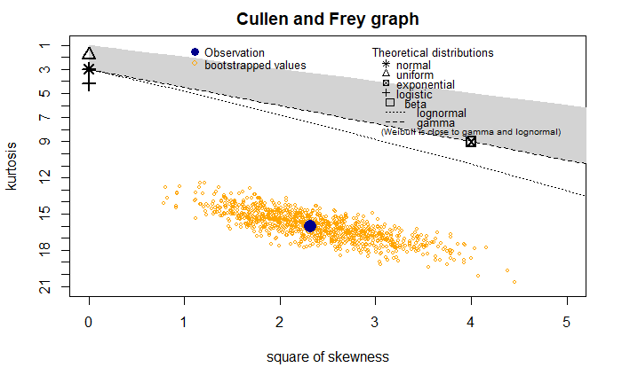

```r
descdist(dataframe_diff30$USD1MTD156N, boot = 1000)
```

```
summary statistics
------
min:  -1.75   max:  1.75
median:  0
mean:  -0.01140635
estimated sd:  0.3554812
estimated skewness:  -0.3479526
estimated kurtosis:  5.859461
```

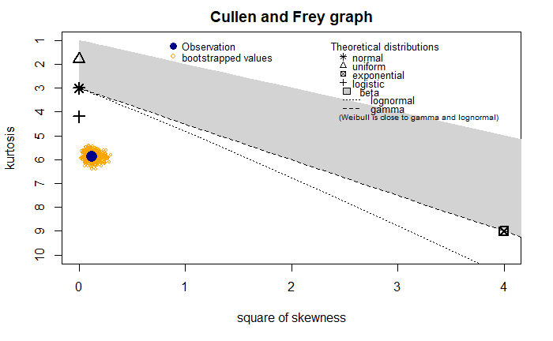

```r
descdist(dataframe_diff30$USD12MD156N, boot = 1000)
```